# brms ja rstanarm

```r
library(tidyverse)
library(rstanarm)
library("brms")
```

# Hierarchical models

## brms

|  | time | censored | patient | recur | age | sex | disease |
| --- | --- | --- | --- | --- | --- | --- | --- |
| 1 | 8 | 0 | 1 | 1 | 28 | male | other |
| 2 | 23 | 0 | 2 | 1 | 48 | female | GN |
| 3 | 22 | 0 | 3 | 1 | 32 | male | other |

Variable time represents the recurrence time of the infection, censored indicates if time is right censored (1) or not censored (0), variable patient is the patient id, and recur indicates if it is the first or second recurrence in that patient. Finally, age, sex, and disease make up the predictors.

fit1 <- brm(formula = time | cens(censored) ~ age * sex + disease + (1 + age|patient), data = kidney, family = lognormal(), prior = c(set_prior(“normal(0,5)”, class = “b”), set_prior(“cauchy(0,2)”, class = “sd”), set_prior(“lkj(2)”, class = “cor”)), warmup = 1000, iter = 2000, chains = 4, control = list(adapt_delta = 0.95))

Everything before the ∼ sign relates to the response part of formula. Usually this is just one variable name. To incorporate additional information about the response, add one or more terms of the form | fun(variable). fun may be one of a few functions defined internally in brms and variable corresponds to a variable in the data supplied by the user. In this example, cens makes up the function that handles censored data, and censored is the variable that contains information on the censoring. Other available functions are weights and disp to allow different sorts of weighting, se to specify known standard errors primarily for meta-analysis, trunc to define truncation boundaries, trials for binomial models, and cat to specify the number of categories for ordinal models.

Everything on the right side of ∼ specifies predictors. Group-level terms are of the form (coefs | group), where coefs contains one or more variables whose effects are assumed to vary with the levels of the grouping factor given in group. Multiple grouping factors each with multiple group-level coefficients are possible. In the present example, only one group-level term is specified in which 1 + age are the coefficients varying with the grouping factor patient. This implies that the intercept of the model as well as the effect of age is supposed to vary between patients. By default, group-level coefficients within a grouping factor are assumed to be correlated.

Argument family: a call to a family function or a character string naming the family. If not otherwise specified, default link functions are applied. Linear and robust linear regression can be performed using the gaussian or student family combined with the identity link. For dichotomous and categorical data, families bernoulli, binomial, and categorical combined with the logit link, by default. Families poisson, negbinomial, and geometric allow for modeling count data. Families lognormal, Gamma, exponential, and weibull can be used (among others) for survival regression. Ordinal regression can be performed using the families cumulative, cratio, sratio, and acat. Finally, families zero_inflated_poisson, zero_inflated_negbinomial, zero_inflated_binomial, zero_inflated_beta, hurdle_poisson, hurdle_negbinomial, and hurdle_gamma can be used to model excess zeros in the response.

In our example, we use family = lognormal() implying a log-normal “survival” model for the response variable time.

### Priors

population-level effects have their corresponding regression parameter, which are named as b_, where represents the name of the population-level effect. **The default prior is an improper flat prior.**

check which parameters can have priors get_prior(rating ~ treat + period + carry + (1|subject), data = inhaler, family = cumulative())

```
      ## define some priors
```

prior <- c(prior_string(“normal(0,10)”, class = “b”), prior(normal(1,2), class = b, coef = treat), prior_(~cauchy(0,2), class = ~sd, group = ~subject, coef = ~Intercept))

The functions prior, prior_, and prior_string are aliases of set_prior each allowing for a differnt kind of argument specification. prior allows specifying arguments as expression without quotation marks using non-standard evaluation. prior_ allows specifying arguments as one-sided formulas or wrapped in quote. prior_string allows specifying arguments as strings just as set_prior itself.

1. Population-level (‘fixed’) effects: x1 and x2 have regression parameters b_x1 and b_x2 respectively. a normal prior with mean 0 and standard deviation 5 for x1, and a unit student-t prior with 10 degrees of freedom for x2:

set_prior(“normal(0,5)”, class = “b”, coef = “x1”) and

set_prior(“student_t(10,0,1)”, class = “b”, coef = “x2”).

To put the same prior on all population-level effects at once.

This also leads to faster sampling.

set_prior(“normal(0,2)”, class = “b”), set_prior(“normal(0,10)”, class = “b”, coef = “x1”)

will set a normal(0,10) prior on the effect of x1 and a normal(0,2) prior on all other population-level effects.

general priors on class “b” will not affect the intercept. Instead, the intercept has its own parameter class named “Intercept” and priors can thus be specified via set_prior(“”, class = “Intercept”). Technially, this prior is set on an intercept that results when internally centering all population-level predictors around zero to improve sampling efficiency. On this centered intercept, specifying a prior is actually much easier and intuitive than on the original intercept, since the former represents the expected response value when all predictors are at their means.

If desired, population-level effects can be restricted to fall only within a certain interval using the lb and ub arguments of set_prior. This is often required when defining priors that are not defined everywhere on the real line, such as uniform or gamma priors. When defining a uniform(2,4) prior, you should write set_prior(“uniform(2,4)”, lb = 2, ub = 4). When using a prior that is defined on the postive reals only (such as a gamma prior) set lb = 0.

Standard deviations of group-level (‘random’) effects

Each group-level effect of each grouping factor has a standard deviation named sd__. Consider, for instance, the formula y ~ x1 + x2 + (1 + x1 | g). We see that the intercept as well as x1 are group-level effects nested in the grouping factor g. The corresponding standard deviation parameters are named as sd_g_Intercept and sd_g_x1 respectively. These parameters are restriced to be non-negative and, by default, have a half student-t prior with 3 degrees of freedom and a scale parameter that depends on the standard deviation of the response after applying the link function. Minimally, the scale parameter is 10. This prior is used (a) to be only very weakly informative in order to influence results as few as possible, while (b) providing at least some regularization to considerably improve convergence and sampling efficiency. To define a prior distribution only for standard deviations of a specific grouping factor, use set_prior(“”, class = “sd”, group = “”). To define a prior distribution only for a specific standard deviation of a specific grouping factor, you may write set_prior(“”, class = “sd”, group = “”, coef = “”).

**verify that the priors indeed found their way into Stan’s model code**

make_stancode(rating ~ treat + period + carry + (1|subject), data = inhaler, family = cumulative(), prior = prior)

[output not shown]

[output not shown]

Each group-level effect of each grouping factor has a standard deviation parameter, which is restricted to be non-negative and, by default, has a half Student-t prior with 3 degrees of freedom and a scale parameter that is minimally 10.

In brms, standard deviation parameters are named as sd__ so that sd_patient_Intercept and sd_patient_age are the parameter names in the example. If desired, it is possible to set a different prior on each parameter, but statements such as

set_prior(“student_t(3,0,5)”, class = “sd”, group = “patient”) or even

set_prior(“student_t(3,0,5)”, class = “sd”)

may also be used and are again faster because of vectorization.

If there is more than one group-level effect per grouping factor, correlations between group-level effects are estimated. the LKJ-Correlation prior with pa- rameter ζ > 0 is used. In brms correlation matrix parameters are named as cor_, (e.g., cor_patient), so that set_prior(“lkj(2)”, class = “cor”, group = “patient”) is a valid statement. To set the same prior on every correlation matrix in the model, set_prior(“lkj(2)”, class = “cor”) is also allowed

```r
LOO(fit1, fit2, fit3, fit4)
```

[output not shown]

```
             LOOIC    SE
fit1        910.88 21.59
fit2        964.89 24.46
fit3        917.19 22.25
fit4        916.50 21.84
fit1 - fit2 -54.01 17.49
fit1 - fit3  -6.32  0.85
fit1 - fit4  -5.62  0.59
fit2 - fit3  47.70 17.46
fit2 - fit4  48.39 17.35
fit3 - fit4   0.69  0.63
```

```r
summary(fit1)
```

```
There were 28 divergent transitions after warmup. Increasing adapt_delta above 0.95 may help.
See http://mc-stan.org/misc/warnings.html#divergent-transitions-after-warmup
```

[output not shown]

## Graphical checks

```r
fit3_data <- as.data.frame(fit3)
names(fit3_data)
```

```
 [1] "b_Intercept"
 [2] "b_l_GDP"
 [3] "sd_continent__Intercept"
 [4] "sd_continent__l_GDP"
 [5] "cor_continent__Intercept__l_GDP"
 [6] "sigma"
 [7] "r_continent.Africa.Intercept."
 [8] "r_continent.Americas.Intercept."
 [9] "r_continent.Asia.Intercept."
[10] "r_continent.Europe.Intercept."
[11] "r_continent.Oceania.Intercept."
[12] "r_continent.Africa.l_GDP."
[13] "r_continent.Americas.l_GDP."
[14] "r_continent.Asia.l_GDP."
[15] "r_continent.Europe.l_GDP."
[16] "r_continent.Oceania.l_GDP."
[17] "lp__"
```

```r
datafit <- fit3$data
```

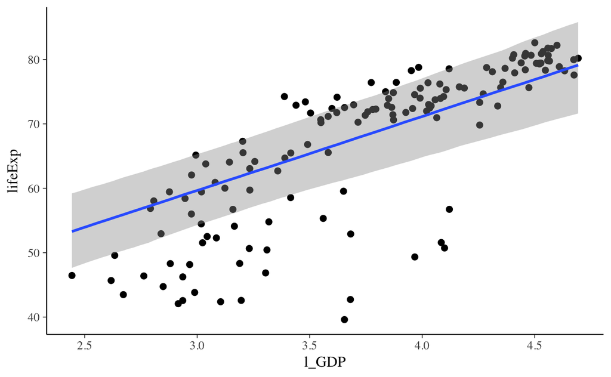

```r
cond <- data.frame(continent="Africa")
plot(marginal_effects(fit3), condition=cond, points=T)
```

```r
aaa <- marginal_effects(fit3, condition=cond)
```

```
The following variables in 'conditions' are not part of the model:
'continent'
```

```r
aaa <- as.data.frame(aaa$l_GDP)
```

#### the posterior predictive check

the dark line represents the density of the observed response, while each light blue line represents draws from the posterior-predictive distribution, that is the distribution of the response as predicted by the model.

[output not shown]

Similar densities of observed and model-implied responses give a first indication of the appropriateness of the model, although two models with similar posterior-predictive distribution might perform differently when it comes to actual prediction of new data. There is an increasing number of posterior-predictive checks to apply via pp_check — help(“PPC-overview”). To get a sense of bad model fit, try modeling skewed data (e.g., response or survival times) using a normal model.

```
Using 10 posterior samples for ppc type 'dens_overlay' by default.
```

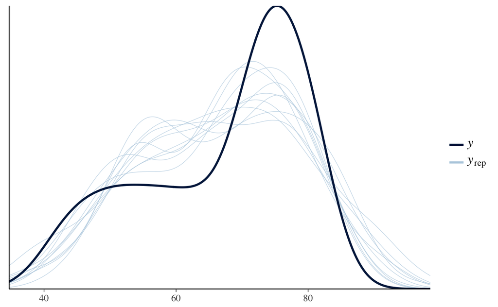

```r
pp_check(fit3)
```

```r
help("PPC-overview")
```

alternatiivne vaade - 5 ennustust heledalt ja tegelikud y andmed.

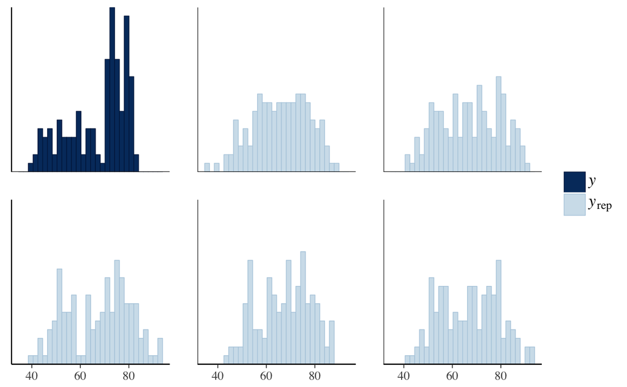

#### Visualizing the posteriors

```r
fit3d <- as.data.frame(fit3$fit)
pars <- names(fit3d)
pars
```

```
 [1] "b_Intercept"
 [2] "b_l_GDP"
 [3] "sd_continent__Intercept"
 [4] "sd_continent__l_GDP"
 [5] "cor_continent__Intercept__l_GDP"
 [6] "sigma"
 [7] "r_continent[Africa,Intercept]"
 [8] "r_continent[Americas,Intercept]"
 [9] "r_continent[Asia,Intercept]"
[10] "r_continent[Europe,Intercept]"
[11] "r_continent[Oceania,Intercept]"
[12] "r_continent[Africa,l_GDP]"
[13] "r_continent[Americas,l_GDP]"
[14] "r_continent[Asia,l_GDP]"
[15] "r_continent[Europe,l_GDP]"
[16] "r_continent[Oceania,l_GDP]"
[17] "lp__"
```

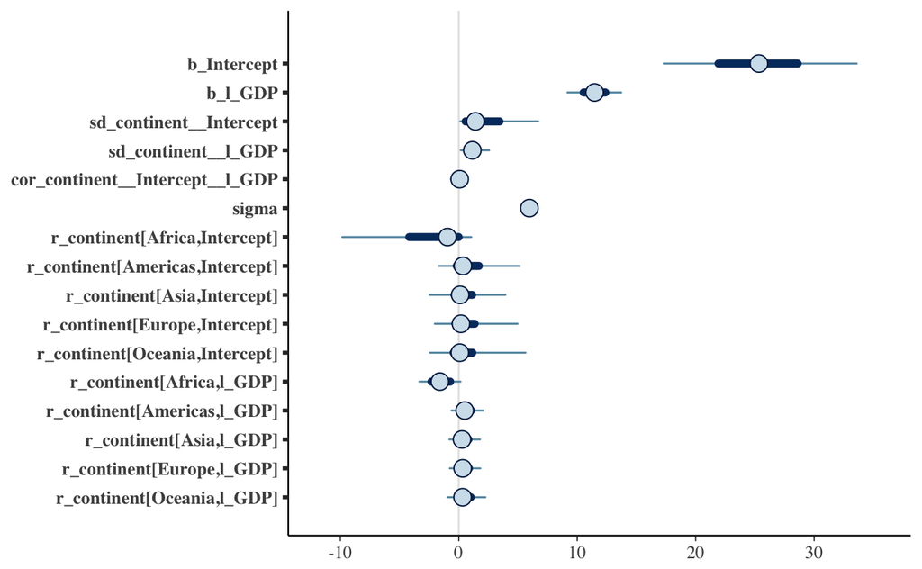

```r
mcmc_intervals(fit3d, pars=pars[-17]) #with pars left out the last parameter lp_
```

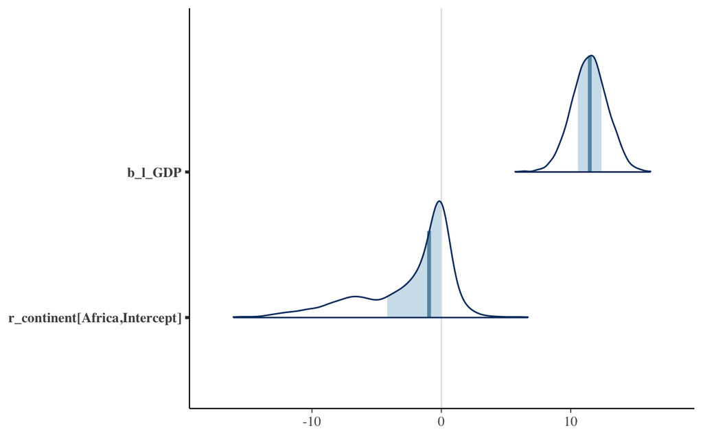

```r
mcmc_areas(fit3d, pars= c("b_l_GDP", "r_continent[Africa,Intercept]"))
```

#### control the sampling process

Stan will throw out a warning suggesting to increase max_treedepth, which can be accomplished by writing control = list(max_treedepth = ) with a positive integer that should usually be larger than the current default of 10.

The model code and data for the present example can be extracted through **stancode(fit1)** and **standata(fit1)**.

model summary with **summary(fit1)**

In general, every parameter is summarized using the mean (Estimate) and the standard deviation (Est.Error) of the posterior distribution as well as two-sided 95% Credible intervals (l-95% CI and u-95% CI) based on quantiles.

An even more detailed investigation can be achieved by applying the shinystan package: **launch_shiny**

`hypothesis(fit1, "Intercept - age > 0", class = "sd", group = "patient")`

Hypothesis Tests for class sd_patient: Estimate Est.Error l-95% CI u-95% CI Evid.Ratio Intercept-age > 0 0.39 0.27 0.03 Inf 67.97

The one-sided 95% credibility interval does not contain zero, thus indicating that the standard deviations differ from each other in the expected direction. In accordance with this finding, the Evid.Ratio shows that the hypothesis being tested (i.e., Intercept - age > 0) is about 68 times more likely than the alternative hypothesis Intercept - age < 0.

Laseme 2s grupis SD-d vabaks ja hindame nende erinevuse.

```r
group <- rep(c("treat", "placebo"), each = 30)
symptom_post <- c(rnorm(30, mean = 1, sd = 2), rnorm(30, mean = 0, sd = 1))
dat1 <- data.frame(group, symptom_post)
head(dat1)
```

|  | group | symptom_post |
| --- | --- | --- |
| 1 | treat | 2.1062954 |
| 2 | treat | 0.3204988 |
| 3 | treat | 3.9537650 |
| 4 | treat | 2.4396809 |
| 5 | treat | 2.3241105 |
| 6 | treat | -0.2615908 |

```r
fit1 <- brm(bf(symptom_post ~ group, sigma ~ group),
            data = dat1, family = gaussian())
```

```r
summary(fit1)
```

me saame kaks regressioonijoont: keskmisele (mu=Intercept + grouptreat x group) ja sd-le (sigma= sigma_intercept + sigma_grouptreat x group). Arvesta, et group= 1 või 0 ja grouptreat=1.

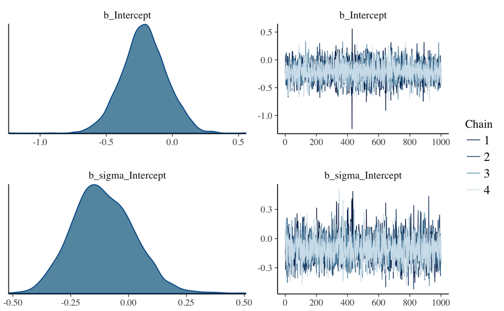

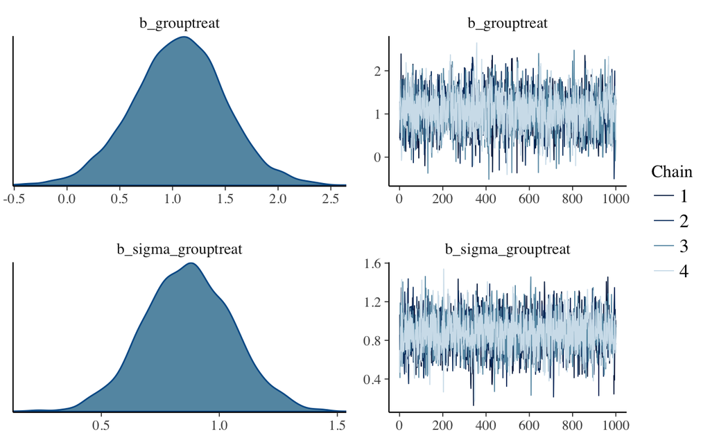

```r
plot(fit1, N=2, ask=F)
```

sigma_grouptreat, which is the contrast of the two residual standard deviations on the log-scale. we can compute the residual standard deviations on the original scale using the hypothesis method.

**Marginal effect** definitsioon: y väärtus, kui x1 = a, x2=b jne.

Marginal effects plot: Display marginal effects of one or more numeric and/or categorical predictors including two-way interaction effects.

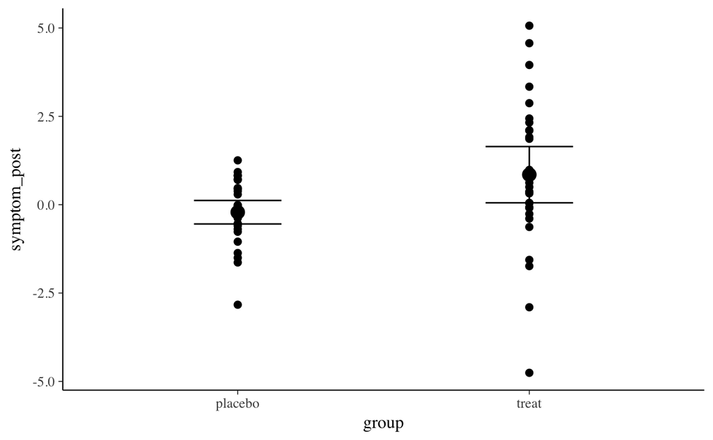

```r
plot(marginal_effects(fit1), points = TRUE)
```

```r
hyp <- c("exp(sigma_Intercept) = 0",
         "exp(sigma_Intercept + sigma_grouptreat) = 0")
hypothesis(fit1, hyp)
```

```
Hypothesis Tests for class b:
                            Estimate Est.Error l-95% CI u-95% CI
(exp(sigma_Interc... = 0        0.90      0.12     0.70     1.18
(exp(sigma_Interc... = 0 #1     2.15      0.29     1.68     2.80
                            Evid.Ratio Star
(exp(sigma_Interc... = 0            NA    *
(exp(sigma_Interc... = 0 #1         NA    *
---
'*': The expected value under the hypothesis lies outside the 95% CI.
```

We may also directly compare them and plot the posterior distribution of their difference.

```r
hyp <- "exp(sigma_Intercept + sigma_grouptreat) > exp(sigma_Intercept)"
(hyp <- hypothesis(fit1, hyp))
```

```
Hypothesis Tests for class b:
                         Estimate Est.Error l-95% CI u-95% CI Evid.Ratio
(exp(sigma_Interc... > 0     1.25      0.32     0.79      Inf        Inf
                         Star
(exp(sigma_Interc... > 0    *
---
'*': The expected value under the hypothesis lies outside the 95% CI.
```

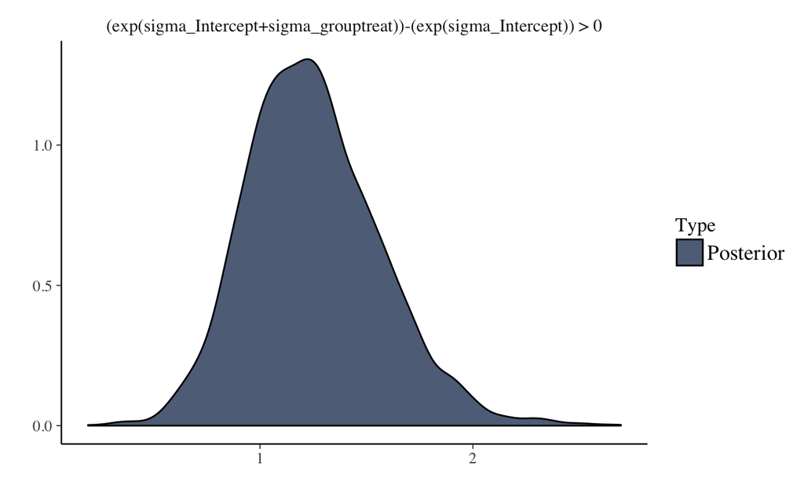

```r
plot(hyp, chars = NULL)
```

See on delta sigma posteerior

Nii saab mudeli koefitsientide fitid (posteeriorid)

```r
f <- fit1$fit %>% as.data.frame()
```

In many applications, we have no or only a very vaque idea how the relationship between a predictor and the response looks like. A very flexible approach to tackle this problems is to use splines and let them figure out the form of the relationship. 4 term additive model.

```r
dat_smooth <- mgcv::gamSim(eg = 6, n = 200, scale = 2, verbose = FALSE)
```

```
Gu & Wahba 4 term additive model
```

```r
head(dat_smooth)
```

|  | y | x0 | x1 | x2 | x3 | f | f0 | f1 | f2 | f3 | fac |
| --- | --- | --- | --- | --- | --- | --- | --- | --- | --- | --- | --- |
| 1 | 17.072726 | 0.4729098 | 0.7672140 | 0.2326454 | 0.6784006 | 18.54927 | 1.9927613 | 4.638672 | 8.91783307 | 0 | 1 |
| 2 | 15.224700 | 0.7697837 | 0.6811025 | 0.1334081 | 0.6667236 | 16.89989 | 1.3236430 | 3.904794 | 5.67145154 | 0 | 2 |
| 3 | 10.327774 | 0.2160154 | 0.4182065 | 0.0197289 | 0.6632077 | 12.62645 | 1.2554580 | 2.308073 | 0.06291735 | 0 | 3 |
| 4 | 25.314980 | 0.4138440 | 0.9918774 | 0.7092389 | 0.3892554 | 23.97294 | 1.9271855 | 7.269989 | 2.77576872 | 0 | 4 |
| 5 | 18.199271 | 0.5610036 | 0.5949626 | 0.2809929 | 0.8080065 | 16.46657 | 1.9633831 | 3.286835 | 8.21635369 | 0 | 1 |
| 6 | 6.028951 | 0.9327223 | 0.7253467 | 0.8076628 | 0.5332538 | 11.65193 | 0.4195781 | 4.266072 | 0.96628415 | 0 | 2 |

The data contains the predictors x0 to x3 as well as the grouping factor fac indicating the nested structure of the data. We predict the response variable y using smooth terms of x1 and x2 and a varying intercept of fac. In addition, we assume the sigma to vary by a smoothing term of x0 and a varying intercept of fac.

```r
fit_smooth1 <- brm(bf(y ~ s(x1) + s(x2) + (1|fac), sigma ~ s(x0) + (1|fac)),
                   data = dat_smooth, family = gaussian(),
                   chains = 2, control = list(adapt_delta = 0.95))
```

[output not shown]

```
There were 3 divergent transitions after warmup. Increasing adapt_delta above 0.95 may help. See
http://mc-stan.org/misc/warnings.html#divergent-transitions-after-warmupExamine the pairs() plot to diagnose sampling problems
```

```r
summary(fit_smooth1)
```

```
There were 3 divergent transitions after warmup. Increasing adapt_delta above 0.95 may help.
See http://mc-stan.org/misc/warnings.html#divergent-transitions-after-warmup
```

```
 Family: gaussian(identity)
Formula: y ~ s(x1) + s(x2) + (1 | fac)
         sigma ~ s(x0) + (1 | fac)
   Data: dat_smooth (Number of observations: 200)
Samples: 2 chains, each with iter = 2000; warmup = 1000; thin = 1;
         total post-warmup samples = 2000
    ICs: LOO = Not computed; WAIC = Not computed

Smooth Terms:
                 Estimate Est.Error l-95% CI u-95% CI Eff.Sample Rhat
sds(sx1_1)           3.49      2.58     0.53    10.03        798 1.01
sds(sx2_1)          17.82      4.74    10.47    29.13        383 1.01
sds(sigma_sx0_1)     0.81      1.02     0.03     3.20        464 1.00

Group-Level Effects:
~fac (Number of levels: 4)
                    Estimate Est.Error l-95% CI u-95% CI Eff.Sample Rhat
sd(Intercept)           6.14      3.31     2.40    14.73        664    1
sd(sigma_Intercept)     0.23      0.30     0.01     1.03        539    1

Population-Level Effects:
                Estimate Est.Error l-95% CI u-95% CI Eff.Sample Rhat
Intercept          15.07      3.54     8.20    21.47        687    1
sigma_Intercept     0.76      0.19     0.44     1.11        579    1
sx1_1               1.80      1.04    -0.51     3.82       1502    1
sx2_1               9.79      2.60     4.81    15.01       1760    1
sigma_sx0_1        -0.03      0.30    -0.75     0.56        662    1

Samples were drawn using sampling(NUTS). For each parameter, Eff.Sample
is a crude measure of effective sample size, and Rhat is the potential
scale reduction factor on split chains (at convergence, Rhat = 1).
```

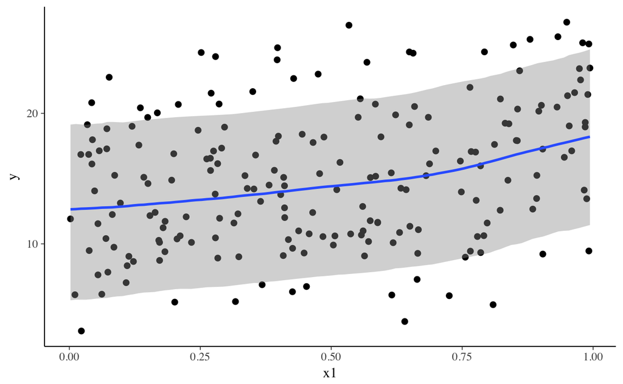

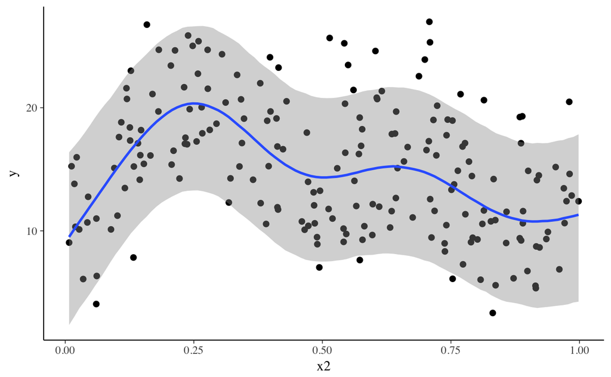

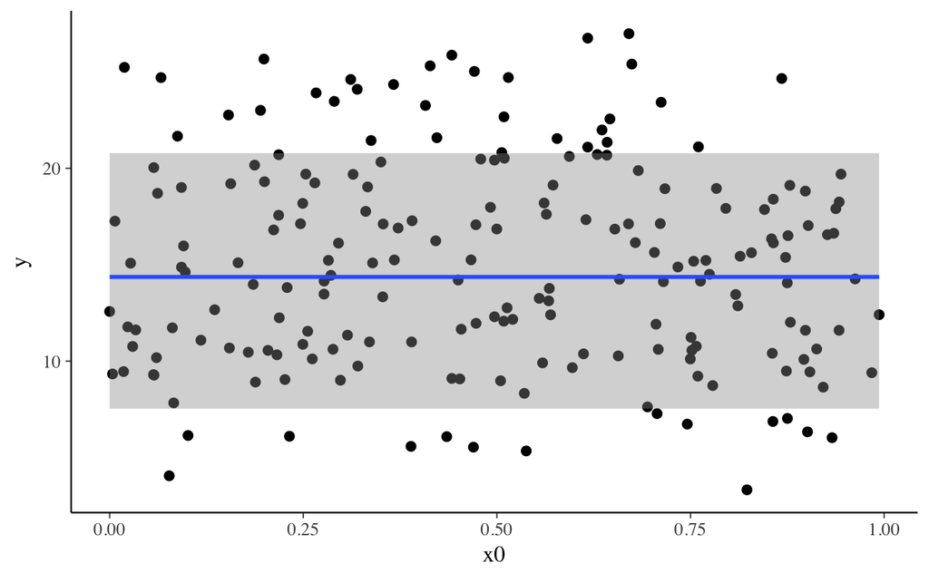

```r
plot(marginal_effects(fit_smooth1), points = TRUE, ask = FALSE)
```